# betting_odds_analysis

## Introduction

This project aims to analyze betting odds data from various bookmakers alongside the outcomes of Premier League matches (Season 2023/2024). The objective is to determine which bookmaker consistently offers the best value odds for different match outcomes.

The dataset includes match data such as the teams playing, scores, and several odds from multiple bookmakers (e.g., Bet365, BetVictor). By performing data cleaning, exploratory analysis, and comparisons, we will identify trends in the odds and determine if some bookmakers offer better odds consistently across the matches.

The dataset used in this project was sourced from **Football-data.co.uk (https://www.football-data.co.uk/englandm.php)**.

Ultimately, this analysis will provide insights into which bookmakers offer the highest potential returns for bettors based on historical data.

## Data Inspection and Cleaning Summary:

```python
import pandas as pd
import numpy as np
import matplotlib.pyplot as plt
import seaborn as sns

# Import data and convert to DataFrame

league = pd.read_csv('premier_league.csv')
league.head()
```

|  | Div | Date | Time | HomeTeam | AwayTeam | FTHG | FTAG | FTR | HTHG | HTAG | ... | AvgC<2.5 | AHCh | B365CAHH | B365CAHA | PCAHH | PCAHA | MaxCAHH | MaxCAHA | AvgCAHH | AvgCAHA |
| --- | --- | --- | --- | --- | --- | --- | --- | --- | --- | --- | --- | --- | --- | --- | --- | --- | --- | --- | --- | --- | --- |
| 0 | E0 | 11/08/2023 | 20:00 | Burnley | Man City | 0 | 3 | A | 0 | 2 | ... | 2.28 | 1.50 | 1.95 | 1.98 | 1.95 | 1.97 | NaN | NaN | 1.92 | 1.95 |
| 1 | E0 | 12/08/2023 | 12:30 | Arsenal | Nott'm Forest | 2 | 1 | H | 2 | 0 | ... | 2.63 | -2.00 | 1.95 | 1.98 | 1.93 | 1.97 | 2.01 | 2.09 | 1.95 | 1.92 |
| 2 | E0 | 12/08/2023 | 15:00 | Bournemouth | West Ham | 1 | 1 | D | 0 | 0 | ... | 2.12 | 0.00 | 2.02 | 1.91 | 2.01 | 1.92 | 2.06 | 1.96 | 1.96 | 1.91 |
| 3 | E0 | 12/08/2023 | 15:00 | Brighton | Luton | 4 | 1 | H | 1 | 0 | ... | 2.48 | -1.75 | 2.01 | 1.92 | 2.00 | 1.91 | 2.14 | 1.93 | 2.00 | 1.86 |
| 4 | E0 | 12/08/2023 | 15:00 | Everton | Fulham | 0 | 1 | A | 0 | 0 | ... | 1.71 | -0.25 | 2.06 | 1.87 | 2.04 | 1.88 | 2.08 | 1.99 | 1.98 | 1.88 |

5 rows × 106 columns

```python
# Display the DataFrame's information (data types, non-null values, memory usage)

league.info()
```

```
<class 'pandas.core.frame.DataFrame'>
RangeIndex: 380 entries, 0 to 379
Columns: 106 entries, Div to AvgCAHA
dtypes: float64(82), int64(16), object(8)
memory usage: 314.8+ KB
```

```python
# Identify missing values in the dataset

def get_non_zero_values(df):
    non_zero_values = df.isna().sum()
    non_zero_values = non_zero_values[non_zero_values != 0]
    if len(non_zero_values > 0):
        return non_zero_values
    else:
        return "No missing values found"

get_non_zero_values(league)
```

```
BWH          2
BWD          2
BWA          2
IWH        182
IWD        182
IWA        182
P>2.5        8
P<2.5        8
BWCH        12
BWCD        12
BWCA        12
IWCH       182
IWCD       182
IWCA       182
PC>2.5       7
PC<2.5       7
MaxCAHH      1
MaxCAHA      1
dtype: int64
```

```python
# Remove columns with more than 10% missing data

def drop_columns(df):
    for column in df:
        if df[column].isna().sum() > len(df) * 0.1:
            df.drop(column, axis='columns', inplace=True)
    return df

league = drop_columns(league)
```

```python
# Get data types of each column that still has missing values

missing_data_type_list = {}

def get_missing_data_types(df):
    for column in df:
        if df[column].isna().sum() != 0:
            missing_data_type_list.update({column:df[column].dtype})
    return missing_data_type_list

get_missing_data_types(league)
```

```
{'BWH': dtype('float64'),
 'BWD': dtype('float64'),
 'BWA': dtype('float64'),
 'P>2.5': dtype('float64'),
 'P<2.5': dtype('float64'),
 'BWCH': dtype('float64'),
 'BWCD': dtype('float64'),
 'BWCA': dtype('float64'),
 'PC>2.5': dtype('float64'),
 'PC<2.5': dtype('float64'),
 'MaxCAHH': dtype('float64'),
 'MaxCAHA': dtype('float64')}
```

```python
# Fill in missing values with the median of each column

def fill_na_values(df):
    for column in df:
        if df[column].isna().sum() != 0:
            df[column] = df[column].fillna(df[column].median())
    return df

league = fill_na_values(league)
```

```python
# Check if there are any remaining missing values in the data

get_non_zero_values(league)
```

```
'No missing values found'
```

## Data Preparation and Outlier Detection

### Step 1: Data Selection and Filtering

To focus the analysis on the most relevant markets, all columns except for odds related to Home, Away, Draw, and Over/Under 2.5 goals per game were removed. The following bookmakers were included in the analysis: `B365`, `BW`, `PS`, `P`, `WH`, and `VC`.

#### Markets Considered:

- Home Win (`H`)
- Away Win (`A`)
- Draw (`D`)
- Over 2.5 Goals (`>2.5`)
- Under 2.5 Goals (`<2.5`)

These columns were extracted and stored in a new DataFrame (`league_HAD_OU`). After organizing the columns, new columns were added to identify the maximum (`Max_X`) and minimum (`Min_X`) odds for each outcome (e.g., Home, Away, Draw, Over/Under 2.5). Additionally, the corresponding bookmakers offering the max and min odds for each outcome were recorded.

### Step 2: Visualization with Boxplots for Outlier Detection

Boxplots were generated to visualize the distribution of odds for Home, Away, Draw, and Over/Under 2.5 goals across multiple bookmakers. Each boxplot shows the range of values (excluding outliers) and helps detect potential anomalies.

Below is the plot with boxplots for the maximum and minimum odds across different markets:

### Analysis of Boxplots:

The boxplots above represent the distribution of maximum and minimum odds for each market (Home, Away, Draw, Over/Under 2.5 goals). Several key observations can be made:

1. **Max_Home & Min_Home**: The odds for home wins display a relatively concentrated distribution, especially for the minimum odds, with few extreme outliers. The maximum odds have a wider spread, indicating greater variation between bookmakers in the highest odds offered.
2. **Max_Away & Min_Away**: Similar to home odds, away odds show a wider range in maximum values, with several outliers extending above 15. These high odds likely correspond to weaker teams playing against stronger opponents, a common occurrence in football betting.
3. **Max_Draw & Min_Draw**: Draw odds tend to be more stable, but outliers exist in both maximum and minimum odds. High draw odds, particularly in the Max_Draw column, could indicate matches where a draw is perceived as very unlikely by most bookmakers.
4. **Over/Under 2.5 Goals**: The distribution of Over/Under odds shows fewer extreme outliers. This market is generally more stable, with odds clustering within expected ranges. However, some matches present odds over 4.0, which may indicate unique situations or perceived low probability of certain outcomes.

### Discussion of Outliers:

While outliers are present in the boxplots, particularly in the Away and Draw markets, it is important to note that these outliers may not necessarily indicate data errors. In football betting, it is common to see high odds for underdogs, especially when weaker teams face much stronger ones. Therefore, these outliers can be seen as expected behavior rather than anomalies.

For example, when a weak team plays a strong team, bookmakers often offer high odds for the underdog (e.g., Max_Away or Max_Draw). These odds reflect the low probability of such outcomes, and thus, high odds do not always signify errors in the data but are instead a normal part of football odds generation.

In conclusion, while boxplots are helpful for detecting outliers, in the context of football odds, these outliers represent normal market behavior rather than data anomalies.

```python
# Remove all columns except odds for Home, Away, Draw, and Over/Under 2.5 goals per game, and store in a new DataFrame: league_HAD_OU

bookies = ['B365', 'BW', 'PS', 'P', 'WH', 'VC']
required_markets = ['H', 'A', 'D', '>2.5', '<2.5']

# Generate the required column names
combined_columns = [f"{bookie}{market}" for bookie in bookies for market in required_markets]

# Select only the columns that exist in the DataFrame
required_columns = [col for col in combined_columns if col in league.columns]

# Create the new DataFrame
league_HAD_OU = league[required_columns]
```

```python
# Sort columns in alphabetical order and print the top five rows to review the new DataFrame: league_HAD_OU

league_HAD_OU = league_HAD_OU.sort_index(axis=1, ascending=True)
league_HAD_OU.head()
```

|  | B365<2.5 | B365>2.5 | B365A | B365D | B365H | BWA | BWD | BWH | P<2.5 | P>2.5 | PSA | PSD | PSH | VCA | VCD | VCH | WHA | WHD | WHH |
| --- | --- | --- | --- | --- | --- | --- | --- | --- | --- | --- | --- | --- | --- | --- | --- | --- | --- | --- | --- |
| 0 | 2.20 | 1.67 | 1.33 | 5.5 | 8.00 | 1.34 | 5.25 | 8.75 | 2.29 | 1.68 | 1.37 | 5.51 | 8.58 | 1.33 | 5.25 | 9.50 | 1.25 | 5.0 | 8.00 |
| 1 | 2.75 | 1.44 | 15.00 | 7.0 | 1.18 | 15.50 | 7.50 | 1.17 | 2.93 | 1.42 | 15.67 | 7.86 | 1.18 | 17.00 | 7.50 | 1.14 | 12.00 | 6.5 | 1.12 |
| 2 | 2.00 | 1.90 | 2.55 | 3.4 | 2.70 | 2.55 | 3.40 | 2.65 | 1.99 | 1.90 | 2.71 | 3.47 | 2.70 | 2.63 | 3.30 | 2.63 | 2.30 | 3.2 | 2.62 |
| 3 | 2.30 | 1.62 | 9.00 | 5.5 | 1.33 | 9.00 | 5.50 | 1.32 | 2.40 | 1.62 | 9.61 | 5.65 | 1.33 | 10.00 | 5.25 | 1.29 | 8.50 | 4.6 | 1.25 |
| 4 | 1.89 | 2.01 | 3.30 | 3.4 | 2.20 | 3.25 | 3.40 | 2.20 | 1.89 | 2.00 | 3.35 | 3.45 | 2.27 | 3.25 | 3.30 | 2.20 | 3.00 | 3.2 | 2.10 |

```python
# Create new columns to identify the MIN and MAX odds and bookies for each outcome of each event

# Define the mapping for market groups
market_mapping = {
    'H': 'Home',
    'A': 'Away',
    'D': 'Draw',
    '>2.5': 'Over2.5',
    '<2.5': 'Under2.5'
}

# Loop through the market mapping and calculate the max/min for each group along with the bookmaker
for market, label in market_mapping.items():
    # Filter to only include numeric columns (odds)
    market_cols = [col for col in league_HAD_OU.columns if market in col and pd.api.types.is_numeric_dtype(league_HAD_OU[col])]

    # Max and Min odds
    league_HAD_OU[f'Max_{label}'] = league_HAD_OU[market_cols].max(axis=1)
    league_HAD_OU[f'Min_{label}'] = league_HAD_OU[market_cols].min(axis=1)

    # Bookmaker offering Max and Min odds
    league_HAD_OU[f'Bookie_Max_{label}'] = league_HAD_OU[market_cols].idxmax(axis=1).str.extract(f'({"|".join(bookies)})')[0]
    league_HAD_OU[f'Bookie_Min_{label}'] = league_HAD_OU[market_cols].idxmin(axis=1).str.extract(f'({"|".join(bookies)})')[0]

# Display the first few rows to check the result
league_HAD_OU.head()
```

|  | B365<2.5 | B365>2.5 | B365A | B365D | B365H | BWA | BWD | BWH | P<2.5 | P>2.5 | ... | Bookie_Max_Draw | Bookie_Min_Draw | Max_Over2.5 | Min_Over2.5 | Bookie_Max_Over2.5 | Bookie_Min_Over2.5 | Max_Under2.5 | Min_Under2.5 | Bookie_Max_Under2.5 | Bookie_Min_Under2.5 |
| --- | --- | --- | --- | --- | --- | --- | --- | --- | --- | --- | --- | --- | --- | --- | --- | --- | --- | --- | --- | --- | --- |
| 0 | 2.20 | 1.67 | 1.33 | 5.5 | 8.00 | 1.34 | 5.25 | 8.75 | 2.29 | 1.68 | ... | PS | WH | 1.68 | 1.67 | P | B365 | 2.29 | 2.20 | P | B365 |
| 1 | 2.75 | 1.44 | 15.00 | 7.0 | 1.18 | 15.50 | 7.50 | 1.17 | 2.93 | 1.42 | ... | PS | WH | 1.44 | 1.42 | B365 | P | 2.93 | 2.75 | P | B365 |
| 2 | 2.00 | 1.90 | 2.55 | 3.4 | 2.70 | 2.55 | 3.40 | 2.65 | 1.99 | 1.90 | ... | PS | WH | 1.90 | 1.90 | B365 | B365 | 2.00 | 1.99 | B365 | P |
| 3 | 2.30 | 1.62 | 9.00 | 5.5 | 1.33 | 9.00 | 5.50 | 1.32 | 2.40 | 1.62 | ... | PS | WH | 1.62 | 1.62 | B365 | B365 | 2.40 | 2.30 | P | B365 |
| 4 | 1.89 | 2.01 | 3.30 | 3.4 | 2.20 | 3.25 | 3.40 | 2.20 | 1.89 | 2.00 | ... | PS | WH | 2.01 | 2.00 | B365 | P | 1.89 | 1.89 | B365 | B365 |

5 rows × 39 columns

```python
league_HAD_OU.info()
```

```
<class 'pandas.core.frame.DataFrame'>
RangeIndex: 380 entries, 0 to 379
Data columns (total 39 columns):
 #   Column               Non-Null Count  Dtype
---  ------               --------------  -----
 0   B365<2.5             380 non-null    float64
 1   B365>2.5             380 non-null    float64
 2   B365A                380 non-null    float64
 3   B365D                380 non-null    float64
 4   B365H                380 non-null    float64
 5   BWA                  380 non-null    float64
 6   BWD                  380 non-null    float64
 7   BWH                  380 non-null    float64
 8   P<2.5                380 non-null    float64
 9   P>2.5                380 non-null    float64
```

[output cut: 31 more lines]

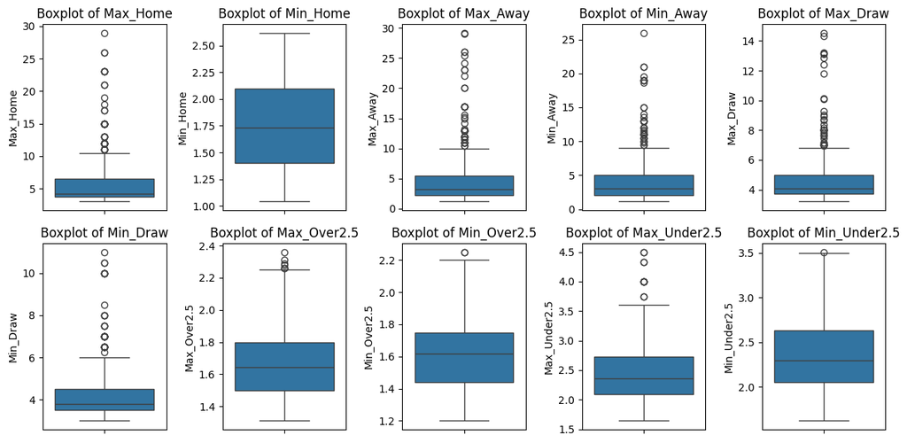

```python
# Plot Max and Min Odds for Outlier Detection

# List of columns to create boxplots for, focusing on the max and min odds columns
columns_to_plot = ['Max_Home', 'Min_Home', 'Max_Away', 'Min_Away', 'Max_Draw', 'Min_Draw', 'Max_Over2.5', 'Min_Over2.5', 'Max_Under2.5', 'Min_Under2.5']

# Create boxplots for each of the specified columns
plt.figure(figsize=(12, 6))  # Adjust size of the plot
for i, column in enumerate(columns_to_plot, 1):
    plt.subplot(2, 5, i)
    sns.boxplot(data=league_HAD_OU[column])
    plt.title(f"Boxplot of {column}")
    plt.tight_layout()

# Save the plot as a PNG file
plt.savefig('plots/boxplot_odds.png')
```

## Exploratory Data Analysis (EDA)

### Step 1: Calculating Average Odds per Bookmaker

The first step in exploratory data analysis involved calculating the average odds offered by each bookmaker for various markets. This calculation excluded the maximum (`Max_`) and minimum (`Min_`) odds, as the focus was on identifying general trends in the average odds offered by each bookmaker. For each bookmaker and market (Home, Away, Draw, Over 2.5, and Under 2.5), the mean odds were computed and stored in a dictionary (`averages`).

### Step 2: Grouping Average Odds by Market

After calculating the average odds, the next step involved grouping these averages by market. Initially, there was an issue where the market label **'H'** (Home) was being incorrectly grouped with **'WHA'** (Away) and **'WHD'** (Draw) due to partial string matching. This caused odds for **WHA** and **WHD** to be grouped incorrectly under the Home market.

To fix this, the logic was updated to ensure that only the exact last character of the market label was matched for single-character markets like **H**, **A**, and **D**. This prevented incorrect grouping by ensuring that markets were only grouped if they exactly matched their intended label.

### Step 3: Visualizing the Average Odds by Market and Bookmaker

With the average odds grouped by market, line plots were generated to visualize how different bookmakers compared across various markets. Each plot shows the bookmakers along the x-axis and their corresponding average odds on the y-axis. Separate line plots were created for the following markets:

- **Home** (H)
- **Away** (A)
- **Draw** (D)
- **Over 2.5 Goals** (>2.5)
- **Under 2.5 Goals** (<2.5)

These visualizations provided an intuitive way to see which bookmaker offered the best odds for each market, allowing for easy comparison across bookmakers.

### Key Findings from the Visualizations

```python
averages = {}

# Caculate avarage odds per bookmaker
def calculate_average_odds(df):
    for column in df:
        if df[column].dtypes == 'float' and 'Max' not in column and'Min' not in column:
            average_odds_calc = df[column].mean()
            averages[column] = float(average_odds_calc)
    return averages

calculate_average_odds(league_HAD_OU)
```

```
{'B365<2.5': 2.418394736842105,
 'B365>2.5': 1.6390789473684209,
 'B365A': 4.5613947368421055,
 'B365D': 4.51,
 'B365H': 2.908973684210526,
 'BWA': 4.549078947368422,
 'BWD': 4.504,
 'BWH': 2.8688157894736843,
 'P<2.5': 2.4231842105263155,
 'P>2.5': 1.6682105263157896,
 'PSA': 4.73328947368421,
 'PSD': 4.690947368421052,
 'PSH': 2.9832105263157893,
 'VCA': 4.767526315789473,
 'VCD': 4.357710526315789,
 'VCH': 2.959157894736842,
 'WHA': 4.53728947368421,
 'WHD': 4.4815000000000005,
 'WHH': 2.8492105263157894}
```

```python
# Split the dictionary created (with average odds) by market for each bookie

def group_by_market(dict):
    grouped_dict = {}
    for key, value in dict.items():
        for item in required_markets:
            if item in key:  # Check if market is part of the key
                if item not in grouped_dict:
                    grouped_dict[item] = []  # Initialize an empty list if not present
                grouped_dict[item].append((key, value))  # Append the bookmaker and odds as a tuple
    return grouped_dict

# Group the dictionary created (with average odds) by market
grouped_dict = group_by_market(averages)
grouped_dict
```

```
{'<2.5': [('B365<2.5', 2.418394736842105), ('P<2.5', 2.4231842105263155)],
 '>2.5': [('B365>2.5', 1.6390789473684209), ('P>2.5', 1.6682105263157896)],
 'A': [('B365A', 4.5613947368421055),
  ('BWA', 4.549078947368422),
  ('PSA', 4.73328947368421),
  ('VCA', 4.767526315789473),
  ('WHA', 4.53728947368421)],
 'D': [('B365D', 4.51),
  ('BWD', 4.504),
  ('PSD', 4.690947368421052),
  ('VCD', 4.357710526315789),
  ('WHD', 4.4815000000000005)],
 'H': [('B365H', 2.908973684210526),
  ('BWH', 2.8688157894736843),
  ('PSH', 2.9832105263157893),
  ('VCH', 2.959157894736842),
  ('WHA', 4.53728947368421),
  ('WHD', 4.4815000000000005),
  ('WHH', 2.8492105263157894)]}
```

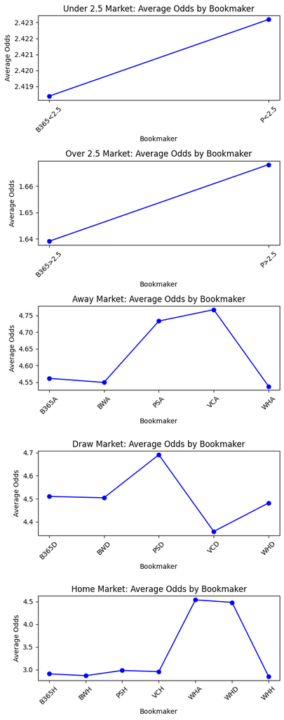

```python
# Plot average odds of each market and for each bookmaker

# Create a dictionary to map short market names to full names
market_labels = {'H': 'Home', 'A': 'Away', 'D': 'Draw', '>2.5': 'Over 2.5', '<2.5': 'Under 2.5'}

# Create a figure with multiple subplots, one for each market
num_markets = len(grouped_dict)  # Number of markets
plt.figure(figsize=(6, num_markets * 3))  # Adjust height depending on the number of markets

# Loop through each market and create a subplot
for i, (market, bookmaker_odds) in enumerate(grouped_dict.items(), 1):
    plt.subplot(num_markets, 1, i)  # Create a subplot for each market

    bookmakers = [bookmaker for bookmaker, odds in bookmaker_odds]  # Get bookmaker names
    odds = [odds for bookmaker, odds in bookmaker_odds]  # Get the odds

    # Plot the line for the current market
    plt.plot(bookmakers, odds, marker='o', label=market_labels.get(market, market), color='blue')

    # Add titles and labels for each subplot
    plt.title(f'{market_labels.get(market, market)} Market: Average Odds by Bookmaker')
    plt.xlabel('Bookmaker')
    plt.ylabel('Average Odds')

    # Rotate the x-axis labels for better readability
    plt.xticks(rotation=45)

# Adjust layout to prevent overlapping
plt.tight_layout()
plt.show()
```

```python
# Fix the grouping of averages per market

def group_by_market(dict):
    grouped_dict = {}
    for key, value in dict.items():
        for item in required_markets:
            # Check the length of the market and match the last part of the string exactly
            if len(item) == 1:  # For 'H', 'A', 'D'
                if key[-1] == item:  # Match only the last character of the key
                    if item not in grouped_dict:
                        grouped_dict[item] = []  # Initialize an empty list if not present
                    grouped_dict[item].append((key, value))  # Append the bookmaker and odds as a tuple
            else:  # For '>2.5', '<2.5'
                if key[-len(item):] == item:  # Match exactly the last part of the string
                    if item not in grouped_dict:
                        grouped_dict[item] = []  # Initialize an empty list if not present
                    grouped_dict[item].append((key, value))  # Append the bookmaker and odds as a tuple
    return grouped_dict


# Group the dictionary created (with average odds) by market
grouped_dict = group_by_market(averages)
grouped_dict
```

```
{'<2.5': [('B365<2.5', 2.418394736842105), ('P<2.5', 2.4231842105263155)],
 '>2.5': [('B365>2.5', 1.6390789473684209), ('P>2.5', 1.6682105263157896)],
 'A': [('B365A', 4.5613947368421055),
  ('BWA', 4.549078947368422),
  ('PSA', 4.73328947368421),
  ('VCA', 4.767526315789473),
  ('WHA', 4.53728947368421)],
 'D': [('B365D', 4.51),
  ('BWD', 4.504),
  ('PSD', 4.690947368421052),
  ('VCD', 4.357710526315789),
  ('WHD', 4.4815000000000005)],
 'H': [('B365H', 2.908973684210526),
  ('BWH', 2.8688157894736843),
  ('PSH', 2.9832105263157893),
  ('VCH', 2.959157894736842),
  ('WHH', 2.8492105263157894)]}
```

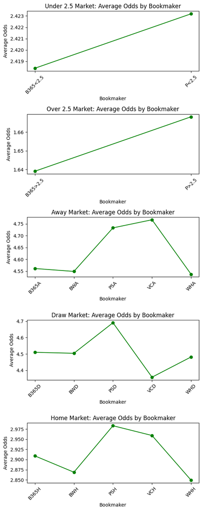

```python
# Plot average odds of each market and for each bookmaker

# Create a dictionary to map short market names to full names
market_labels = {'H': 'Home', 'A': 'Away', 'D': 'Draw', '>2.5': 'Over 2.5', '<2.5': 'Under 2.5'}

# Create a figure with multiple subplots, one for each market
num_markets = len(grouped_dict)  # Number of markets
plt.figure(figsize=(6, num_markets * 3))  # Adjust height depending on the number of markets

# Loop through each market and create a subplot
for i, (market, bookmaker_odds) in enumerate(grouped_dict.items(), 1):
    plt.subplot(num_markets, 1, i)  # Create a subplot for each market

    bookmakers = [bookmaker for bookmaker, odds in bookmaker_odds]  # Get bookmaker names
    odds = [odds for bookmaker, odds in bookmaker_odds]  # Get the odds

    # Plot the line for the current market
    plt.plot(bookmakers, odds, marker='o', label=market_labels.get(market, market), color='green')

    # Add titles and labels for each subplot
    plt.title(f'{market_labels.get(market, market)} Market: Average Odds by Bookmaker')
    plt.xlabel('Bookmaker')
    plt.ylabel('Average Odds')

    # Rotate the x-axis labels for better readability
    plt.xticks(rotation=45)

# Adjust layout to prevent overlapping
plt.tight_layout()
plt.show()
```

# Research Project Summary

This research project aimed to analyze and compare betting odds across various bookmakers for different football markets, including Home, Away, Draw, Over 2.5 goals, and Under 2.5 goals. The primary objective was to explore which bookmakers offer the highest value in terms of odds for different betting markets. The following steps were taken to achieve this:

### 1. Data Preparation and Filtering:

- The initial dataset was filtered to include only the relevant columns related to the Home, Away, Draw, Over 2.5, and Under 2.5 betting markets.
- Outliers were detected and discussed using boxplots to identify any extreme odds that could influence the analysis.